# Explaining Relative Agronomic Efficiency (RAE) Visualizations

Willingthon Pavan

## Introduction

This RMarkdown explains the R code used to visualize and analyze **Relative Agronomic Efficiency (RAE)** data in Tanzania using geospatial visualizations. The code demonstrates how to create static plots with `ggplot2`, transform data into raster formats for heatmap visualizations, and generate interactive maps using the `leaflet` package.

## Required Libraries

We start by loading the required libraries. Each library serves the following purposes:

```r
# Load essential libraries
library(tidyverse)    # For data manipulation and visualization
library(plotly)       # For creating interactive plots
library(raster)       # For raster data manipulation
library(viridis)      # For color scales (e.g., Spectral palette)
library(RColorBrewer) # For creating color palettes
library(leaflet)      # For interactive maps
```

## Loading Data

We load two datasets: 1. `Tanzania-Rae.csv`: Contains RAE data, including coordinates and values. 2. `Tanzania-polygon.csv`: Contains polygon data representing Tanzania’s boundaries.

```r
# Load the datasets
tz_rae <- read_csv("Tanzania-Rae.csv")        # RAE data
tz_polygon <- read_csv("Tanzania-polygon.csv") # Polygon boundary data
```

## Static Visualization with `ggplot2`

This section creates a **static plot** using `ggplot2`.

### Step-by-Step Explanation

1. **Background Map**: We use `geom_polygon` to plot the boundaries of Tanzania.
2. **RAE Data Overlay**: Points representing RAE data are added with `geom_point`. Each point is colored based on the `rae` value.
3. **Coordinate Fixing**: `coord_fixed` ensures the map has correct proportions.
4. **Color Scale**: `scale_color_distiller` applies the **Spectral** color palette to the RAE data.

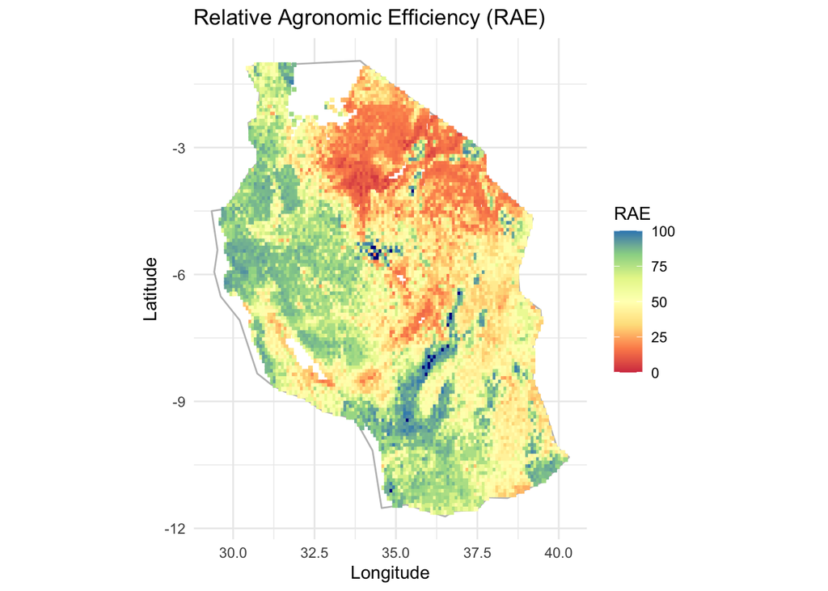

```r
# Create a static plot with ggplot2
plot <- ggplot() +
  geom_polygon(data = tz_polygon, aes(x = long, y = lat),
               fill = "white", color = "gray") + # Plot boundary
  coord_fixed(1.3) + # Fix aspect ratio
  geom_point(data = na.omit(tz_rae),
             aes(x = Longitude, y = Latitude, color = rae),
             shape = 15, size = 1) + # Add RAE points
  labs(x = "Longitude", y = "Latitude",
       title = "Relative Agronomic Efficiency (RAE)") + # Add labels
  theme_minimal() + # Minimal theme for a clean look
  scale_color_distiller("RAE", palette = "Spectral",
                        limits = c(0, 100),
                        na.value = "darkblue",
                        direction = 1) # Spectral color
plot
```

## Heatmaps (Using Rasters)

We will create a **heatmap** of RAE data by transforming the dataset into a raster format.

### Step-by-Step Explanation

1. **Raster Conversion**: The `rasterFromXYZ` function converts the `tz_rae` dataset (with columns `Longitude`, `Latitude`, and `rae`) into a raster object.
2. **Set CRS**: The `crs` function assigns the coordinate reference system (CRS) to WGS84.
3. **Disaggregation**: The raster is refined with `disaggregate`, which increases its resolution by dividing each pixel into smaller pixels.

```r
# Transform data to raster format
raster <- rasterFromXYZ(tz_rae %>%
                          dplyr::select(lon = Longitude,
                                        lat = Latitude, z = rae)) # Convert to raster
crs(raster) <- sp::CRS("+proj=longlat +ellps=WGS84 +datum=WGS84 +no_defs") # Set CRS
raster_dis <- disaggregate(raster, 5, method = 'bilinear') # Refine resolution
```

## Plotting the Raster

### Using Base R

A quick way to visualize the raster is with the `plot` function.

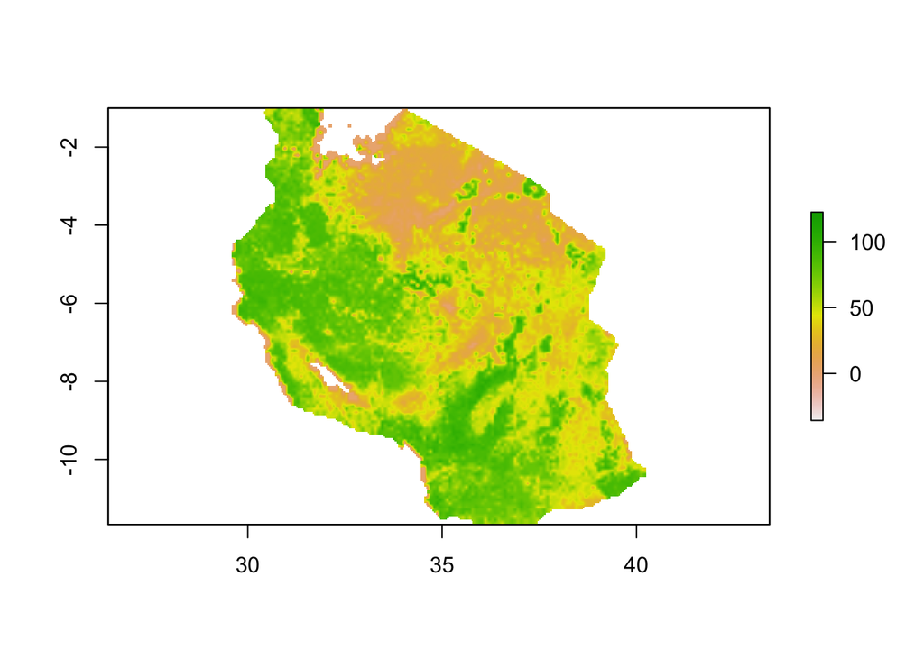

```r
# Basic raster plot
plot(raster_dis)
```

### Using `ggplot2`

For a more customized heatmap, we convert the raster into a dataframe and plot it with `ggplot2`.

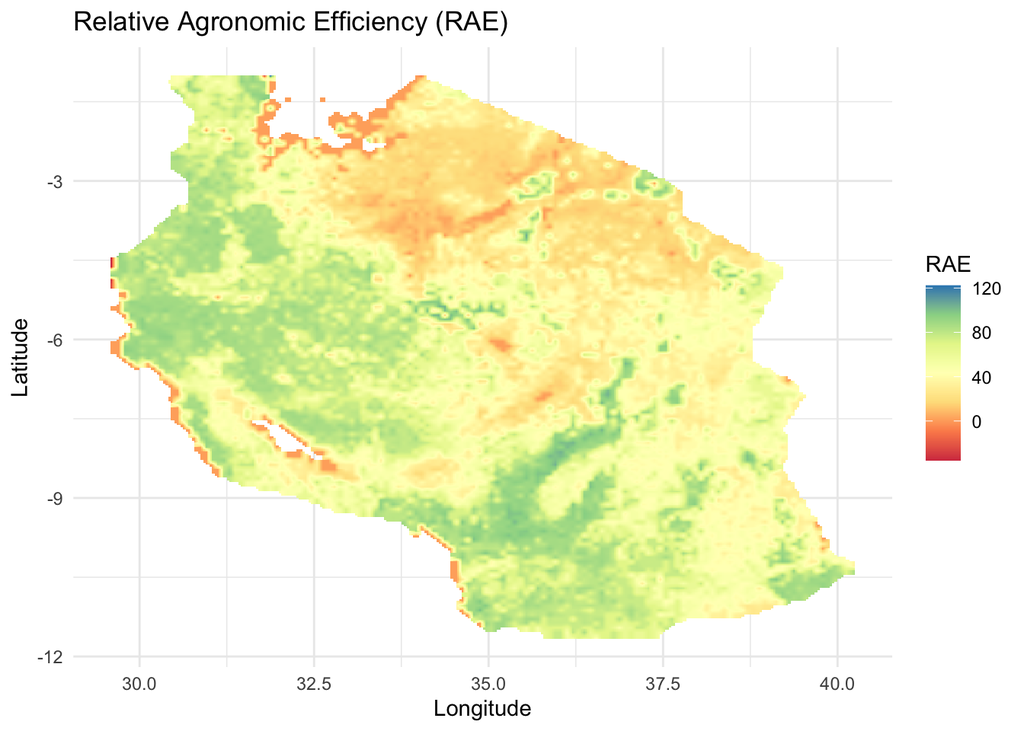

```r
# Convert raster to dataframe for ggplot2
raster_df <- as.data.frame(raster_dis, xy = TRUE, na.rm = TRUE)

# Plot heatmap with ggplot2
ggplot(data = raster_df) +
  geom_tile(aes(x = x, y = y, fill = z)) +
  scale_fill_distiller(
    palette = "Spectral",   # Spectral palette
    direction = 1,          # Normal color direction
    na.value = "transparent" # Transparent for NA values
  ) +
  labs(
    title = "Relative Agronomic Efficiency (RAE)",
    x = "Longitude",
    y = "Latitude",
    fill = "RAE"            # Legend title
  ) +
  theme_minimal()
```

## Using `leaflet`

We use `leaflet` to create an **interactive map** with dynamic color mapping and legends.

### Step-by-Step Explanation

1. **Color Palette**: The `colorNumeric` function creates a numeric color mapping for the Spectral palette.
2. **Add Raster**: `addRasterImage` overlays the raster data onto the map.
3. **Legend**: `addLegend` adds a legend to explain the color scale.

```r
# Create color palette
col <- brewer.pal(11, "Spectral") # Spectral palette

# Reverse domain for color mapping
palLegend <- colorNumeric(
  palette = col,
  domain = rev(seq(0, 100, 10)), # Reverse values for correct mapping
  na.color = "transparent"
)

# Plot interactive map with leaflet
leaflet() %>%
  addTiles() %>% # Add base map
  addRasterImage(raster_dis,
                 colors = palLegend,
                 opacity = 0.6) %>% # Add raster
  addLegend(
    pal = palLegend,
    values = seq(0, 100, 25),  # Legend intervals
    title = "RAE"             # Legend title
  )
```

[interactive chart not shown]

## Conclusion

This RMarkdown explains how to visualize geospatial data effectively using **static**, **heatmap**, and **interactive** visualizations. The integration of `ggplot2`, `raster`, and `leaflet` demonstrates a flexible approach to data exploration and presentation.